[figure not shown]

# Tabla de Contenidos

- Jupyter Notebook
  - 1.1 Introducción
  - 1.2 Ejecución
  - 1.3 Configuración del directorio de trabajo
  - 1.4 Los notebooks de Jupyter
  - 1.5 Elementos de un notebook
  - 1.6 Ejecución de las celdas
  - 1.7 Flujo de edición de una celda
  - 1.8 ¿Qué se puede hacer en un Notebook de IPython?

# Jupyter Notebook

## 1.1. Introducción

- [Jupyter notebook](http://jupyter.org) es una aplicación que permite el uso integrado de códigos de programación junto con presentación de contenidos (texto, fórmulas, figuras, y medios audiovisuales).
- Facilita una explicación más detallada y atractiva de los conceptos que se quieren describir.
- Los documentos generados se visualizan con un navegador (Explorer, Chrome, Firefox, ...) y pueden incluir cualquier elemento accesible a una página web, además de permitir la ejecución de código escrito en el lenguaje de programación Python.
- Jupyter contiene todas las herramientas científicas estándar de Python, y permite realizar taréas típicas en el contexto del análisis de datos: importación y exportación, manipulación y transformación, visualización, etc

## 1.2. Ejecución

Para ejecutar Jupyter hay dos formas:

- Se busca en la instalación realizada el icono de "Jupyter Notebook", y se pulsa sobre el mismo.

[figure not shown]

- Se abre un terminal y se ejecuta el comando `jupyter notebook`.

[figure not shown]

En cualquiera de los casos, aparece una nueva terminal donde se ejecuta la herramienta.

[figure not shown]

Y se lanza un navegador donde se puede acceder a la interface principal del Jupyter Notebook.

[figure not shown]

En la interface principal de la herramienta, pueden aparecer unas cuantas carpetas y tal vez algunos ficheros. Esto se debe a que esta interfaz web actúa como un explorador de archivos. Observar que si el directorio está vacío se abrirá una ventana del navegador con un aspecto similar al siguiente:

[figure not shown]

Así mismo, desde esta interface además de poder moverse entre distintas carpetas (basta pinchar sobre la carpeta correspondiente y se accede al contenido de dicha carpeta), es posible crear nuevos ficheros y carpetas. Para ello se pulsa sobre el desplegable que aparece en la parte derecha denominado **New**, y allí se selecciona **Text File** o **Folder** dependiendo de lo que se quiera crear.

[figure not shown]

En la siguiente captura se ve una nueva carpeta creada:

[figure not shown]

También es posible renombrar y eliminar las carpetas y archivos. Para ello basta seleccionar la correspondiente carpeta o archivo. Una vez seleccionado, en la parte superior aparecen las opciones de **Rename** y el icono de la papelera, que permiten renombrar y eliminar respectivamente.

[figure not shown]

## 1.3. Configuración del directorio de trabajo

Por defecto, Jupyter trabaja en un directorio de trabajo. Sin embargo, es posible crearse un directorio de trabajo propio. Para ello, bien se crea desde la interface el directorio sobre el que se quiere trabajar como se ha visto antes, o bien se abre un terminal, y se navega hasta la carpeta en el que se quiere crear el directorio de trabajo, y allí se crea el directorio `mkdir directorio` . A continuacion se accede al nuevo directorio, y allí se ejecuta `jupyter notebook`

[figure not shown]

## 1.4. Los notebooks de Jupyter

Los notebooks de Jupyter son unos archivos con extensión .ipyb, en los que se puede escribir código python ejecutable, texto, dibujar gráficas y otras operaciones más.

Para crearse un nuevo notebook basta pulsar sobre el desplegable que aparece en la parte superior derecha denominado **New**, y seleccionar en el mismo cualquiera de las opciones etiquetadas como `Python [conda root]` o `Python [default]` que se muestran debajo de `Notebooks`.

[figure not shown]

Una vez pulsado, se carga el nuevo notebook creado

[figure not shown]

## 1.5. Elementos de un notebook

- **Título del notebook**. Cada notebook tiene un título asociado. Por defecto aparece con el nombre **Untitled**.

[figure not shown]

  Para modificarlo, basta pulsar sobre **Untitled**, y aparece una ventana en la que se puede modificar el nombre

[figure not shown]

  Una vez renombrado, aparece el nuevo título en la parte superior del notebook.

[figure not shown]

- **Menús y Barra de herramientas**. En la parte superior de la interface del notebook dispone de un conjunto de menús con diferentes opciones para gestionar los archivos, para editar, visionar,etc

[figure not shown]

  Y justo debajo de los menús, aparece un conjunto de iconos que permite realizar las acciones más comunes sobre los elementos del notebook

[figure not shown]

- **Celdas**: La unidad de edición de un notebook son las celdas. Cada celda contiene código Python o bien la información que documenta dicho código. En este sentido,un notebook es una secuencia de celdas

[figure not shown]

  Las celdas pueden ser de diferentes tipos según el contenido que almacenan:
  - **Markdown**: Permite escribir texto formateado con el objetivo de documentar. Se usa el lenguaje de marcas Markdown

[figure not shown]

  - **Raw NBConvert**: Son celdas que permiten escribir fragmentos de código sin que sean ejecutados.
  - **Heading**: Permite embeber código html.
  - **Code**: Sirven para escribir código Python ejecutable. Están marcadas por la palabra **In [n]** y están numeradas. El resultado de la ejecución de cada celda se muestra en el campo **Out[n]**, también numerado. A continuación se muestra un ejemplo de una celda de código:

[figure not shown]

    Como se puede ver en el ejemplo anterior, ambas celdas tienen el mismo número, indicando que la segunda es el resultado de la primera. La primera celda **In [ ]** contiene código a ejecutar y la segunda celda **Out[ ]** se genera automáticamente como resultado de la ejecución de la primera. Observar que los **comentarios** dentro de secciones de código se hace poniendo el símbolo de gato, #, al inicio de la línea.

Para elegir el tipo de celda a utilizar, se selecciona en un desplegable que aparece en la fila superior junto a los iconos.

[figure not shown]

## 1.6. Ejecución de las celdas

Todas las celdas son susceptibles de ser ejecutadas. La ejecución de una celda de código Python, ejecutará el código escrito en la celda y producirá una salida, que será el resultado de la ejecución. La ejecución de celdas de tipo Markdown, dará formato al texto.

Para ejecutar una celda hay que posicionarse en la celda y posteriormente pulsar el botón cuyo icono es un triángulo mirando a la derecha.De igual forma para parar la ejecución, se pulsa sobre el cuadrado

[figure not shown]

Además de ejecutar las celdas, sobre las celdas se pueden realizar otras acciones de actualización:

- Cortar celdas
- Pegar celdas
- Eliminar celdas
- Cambiar el orden de las celdas

[figure not shown]

Para crear celdas nuevas se pulsa sobre el botón con el icono del signo `+`. En la siguiente imagen se pueden ver distintas celdas de texto. La primera celda es de código, la segunda y cuarta son celdas de texto sin ejecutar, mientras que la tercera es una celda de texto ya ejecutada. Si se hace doble click en una celda ya ejecutada, pasa a ser una celda no ejecutada y se podrá modificar añadiendo o eliminando texto. A continuación, se podrá volver a ejecutar.

[figure not shown]

## 1.7. Flujo de edición de una celda

El flujo normal de edición de una celda consiste en:

- Elegir el tipo de celda.Por defecto son de tipo `Code`.Dependiendo del tipo de celda elegido, Jupyter lo interpretará de diferente manera.
- Una vez introducido el código o texto en la celda,se debe ejecutar.Para ello se pulsa sobre el icono en forma de flecha.
- A continuación se genera una nueva celda para editar.

Por ejemplo si se quiere crear una celda que contenga la función: def multiplica(a,b): return a*b

Y a continuacion se quiere multiplicar 3 por 4, se haría de la siguiente manera:

- En primer lugar se crea una celda pulsando sobre el signo `+` para crear la celda vacía. Como es de tipo `Code` no hace falta cambiar el tipo de celda en el desplegable:

[figure not shown]

- Se copia el texto de la función en la celda

[figure not shown]

- Se ejecuta la celda pulsando sobre el icono en forma de triángulo hacia la derecha

[figure not shown]

- Como resultado de la ejecución, se ha creado una nueva celda de tipo `Code`.Se copia la invocación de la función escrita anteriormente para los valores 3 y 4, multiplica(3,4)

[figure not shown]

- Se ejecuta la celda pulsando sobre el icono en forma de triángulo hacia la derecha, generándose el resultado de la invocación.

[figure not shown]

## 1.8. ¿Qué se puede hacer en un Notebook de IPython?

A continuación se muestran algunos ejemplos de las cosas que se puede hacer en un documento de este tipo, además de ejecutar código

### 1.8.1. Dibujar gráficas

Una de las operaciones típicas con los notebooks es representar gráficamente conjuntos de datos. Para ello existe una librería en Python denominada `Matplotlib` que permite realizar representaciones gráficas tales como la siguiente:

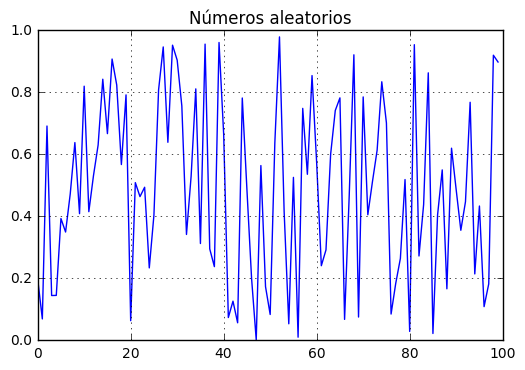

```python
%pylab inline
plot(rand(100))
grid()
title('Números aleatorios');
```

### 1.8.2. Incrustar Imágenes

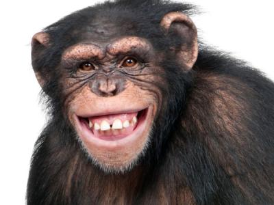

```python
from IPython.display import Image
Image(filename='./imagenes/chimp.jpg')
```

### 1.8.3. Incrustar vídeos

```python
from IPython.display import YouTubeVideo
YouTubeVideo('ShypI8IYy0g')
```

[video not shown]

### 1.8.4. Escribir y representar código HTML

```python
from IPython.display import HTML
s = """<table>
<tr>
<th>Header 1</th>
<th>Header 2</th>
</tr>
<tr>
<td>row 1, cell 1</td>
<td>row 1, cell 2</td>
</tr>
<tr>
<td>row 2, cell 1</td>
<td>row 2, cell 2</td>
</tr>
</table>"""
h = HTML(s)
h
```

| Header 1 | Header 2 |
| --- | --- |
| row 1, cell 1 | row 1, cell 2 |
| row 2, cell 1 | row 2, cell 2 |

### 1.8.5. Exportar e importar los notebooks

Una opción muy interesante de Jupyter es la posibilidad de importar y exportar los notebooks. De esta forma se facilita compartir y reutilizarlos.

Para exportar un notebook, basta tenerlo abierto, y usar el menú File.Se selecciona Download as,y dentro de ese desplegable se elige la opción de exportación.En general se elegirá Notebook(.ipnb). No todas funcionan, pues requieren de tener instaladas librerias adicionales.

[figure not shown]

Para importar un notebook,hay que irse a la página principal de Jupyter,dónde aparecen listados todos los notebooks,y basta arrastrar el notebook que se quiere importar. También se puede cargar el notebook, pulsando sobre la opción `upload`, de manera que aparece un navegador de archivos, desde donde se elige el archivo que se quiere importar.

[figure not shown]

# References

- [Jupyter notebook documentation](http://jupyter.readthedocs.org/en/latest/index.html)